Let us consider the dataframe wine, which contains information about 178 samples of wines grown in the same region in Italy. The cultivar of each wine sample is observed (variable cultivar, with labels 1, 2, 3), together with the concentration of the 13 different chemicals (variables V1-V13). Describe how to perform a preliminary data analysis on this dataframe using suitable R commands and comment the following outputs.

```r
wine <- read.table("./../data/wine.txt", header = TRUE)
wine$cultivar <- factor(wine$cultivar)
summary(wine)
```

```
##  cultivar       V1              V2              V3              V4
##  1:59     Min.   :11.03   Min.   :0.740   Min.   :1.360   Min.   :10.60
##  2:71     1st Qu.:12.36   1st Qu.:1.603   1st Qu.:2.210   1st Qu.:17.20
##  3:48     Median :13.05   Median :1.865   Median :2.360   Median :19.50
##           Mean   :13.00   Mean   :2.336   Mean   :2.367   Mean   :19.49
##           3rd Qu.:13.68   3rd Qu.:3.083   3rd Qu.:2.558   3rd Qu.:21.50
##           Max.   :14.83   Max.   :5.800   Max.   :3.230   Max.   :30.00
##        V5               V6              V7              V8
##  Min.   : 70.00   Min.   :0.980   Min.   :0.340   Min.   :0.1300
##  1st Qu.: 88.00   1st Qu.:1.742   1st Qu.:1.205   1st Qu.:0.2700
##  Median : 98.00   Median :2.355   Median :2.135   Median :0.3400
##  Mean   : 99.74   Mean   :2.295   Mean   :2.029   Mean   :0.3619
##  3rd Qu.:107.00   3rd Qu.:2.800   3rd Qu.:2.875   3rd Qu.:0.4375
##  Max.   :162.00   Max.   :3.880   Max.   :5.080   Max.   :0.6600
##        V9             V10              V11              V12
##  Min.   :0.410   Min.   : 1.280   Min.   :0.4800   Min.   :1.270
##  1st Qu.:1.250   1st Qu.: 3.220   1st Qu.:0.7825   1st Qu.:1.938
##  Median :1.555   Median : 4.690   Median :0.9650   Median :2.780
##  Mean   :1.591   Mean   : 5.058   Mean   :0.9574   Mean   :2.612
##  3rd Qu.:1.950   3rd Qu.: 6.200   3rd Qu.:1.1200   3rd Qu.:3.170
##  Max.   :3.580   Max.   :13.000   Max.   :1.7100   Max.   :4.000
##       V13
##  Min.   : 278.0
##  1st Qu.: 500.5
##  Median : 673.5
##  Mean   : 746.9
##  3rd Qu.: 985.0
##  Max.   :1680.0
```

```r
sapply(wine[2:14],sd)
```

```
##          V1          V2          V3          V4          V5          V6
##   0.8118265   1.1171461   0.2743440   3.3395638  14.2824835   0.6258510
##          V7          V8          V9         V10         V11         V12
##   0.9988587   0.1244533   0.5723589   2.3182859   0.2285716   0.7099904
##         V13
## 314.9074743
```

```r
source("./../functions.R", local = knitr::knit_global())
```

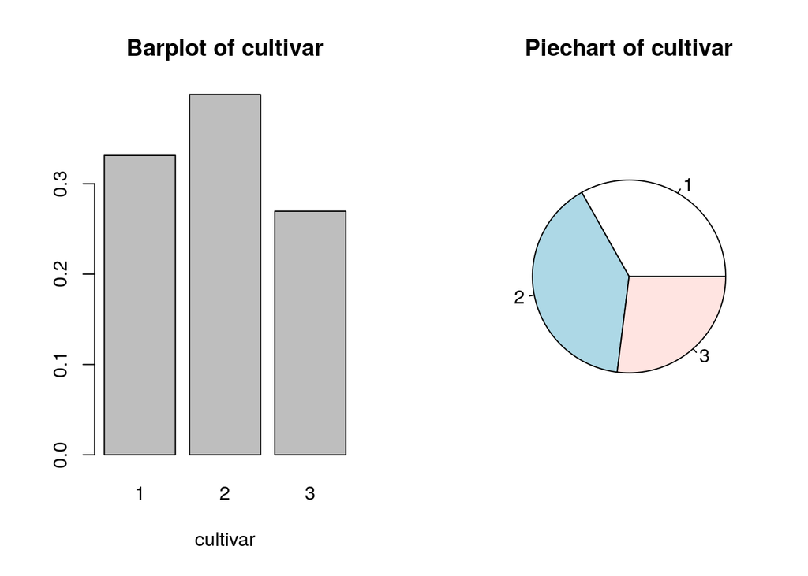

```r
categorical.graph(wine, 1, 1)
```

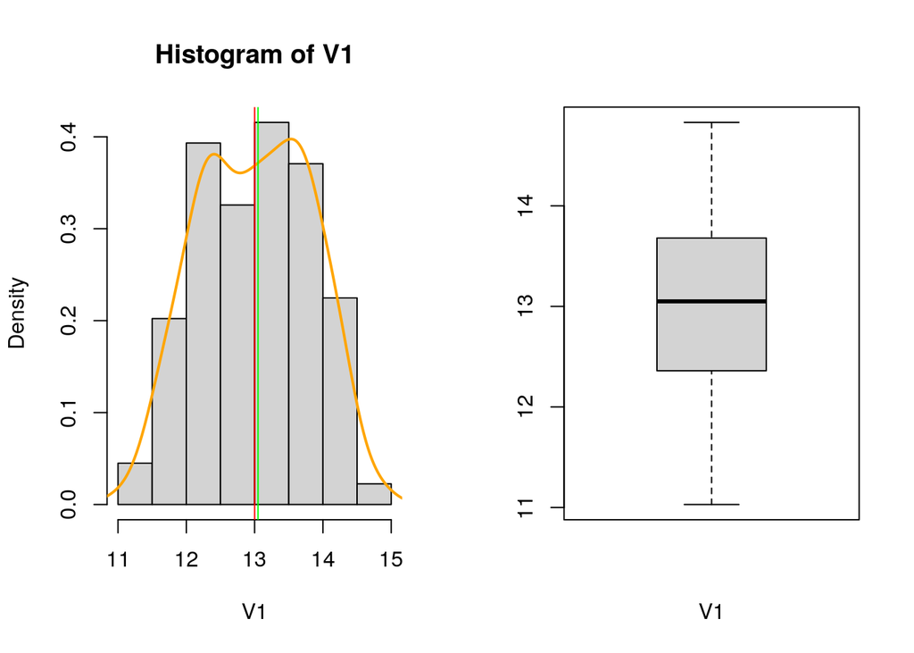

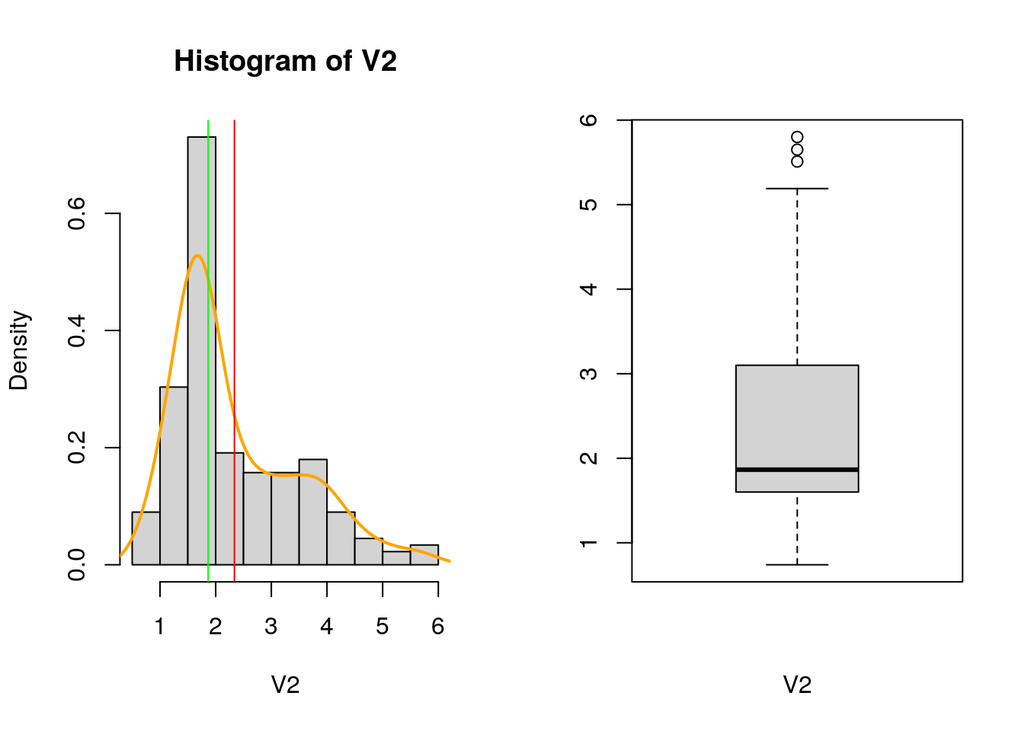

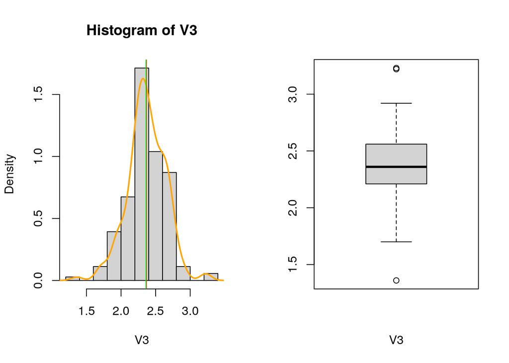

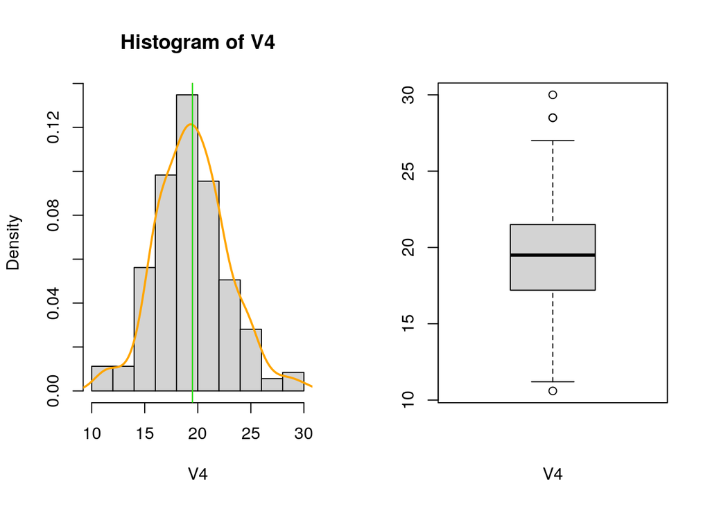

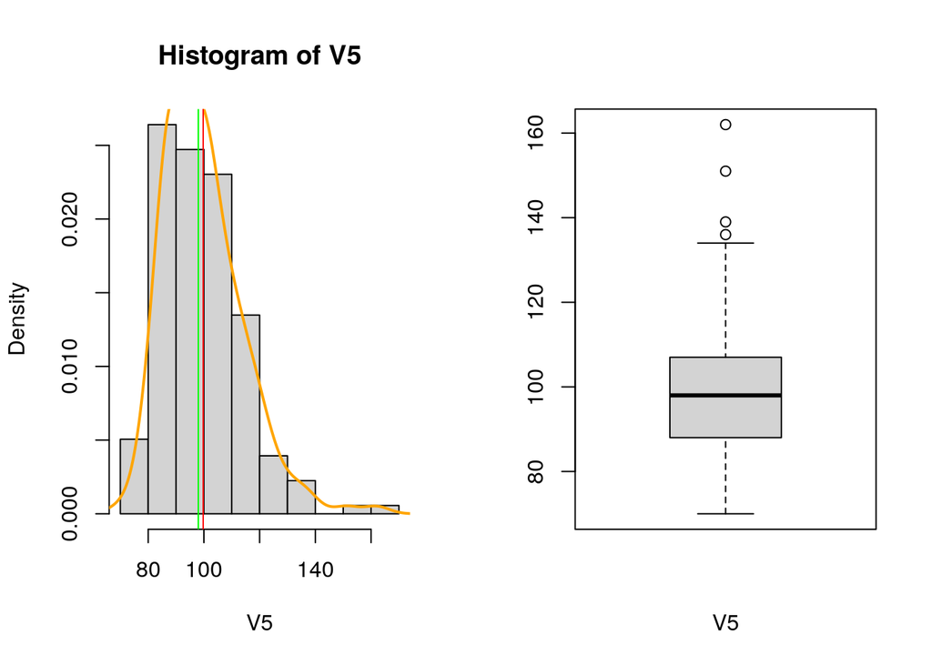

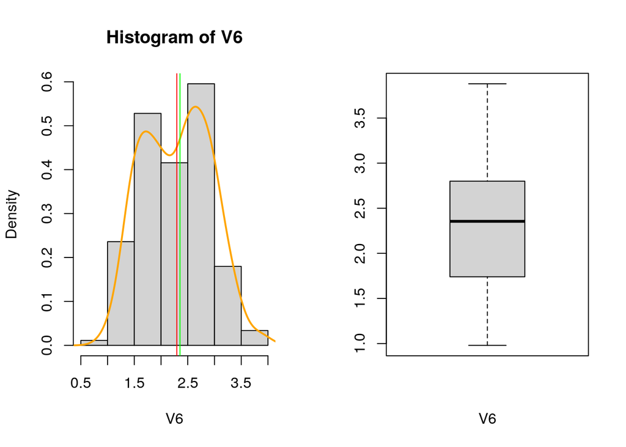

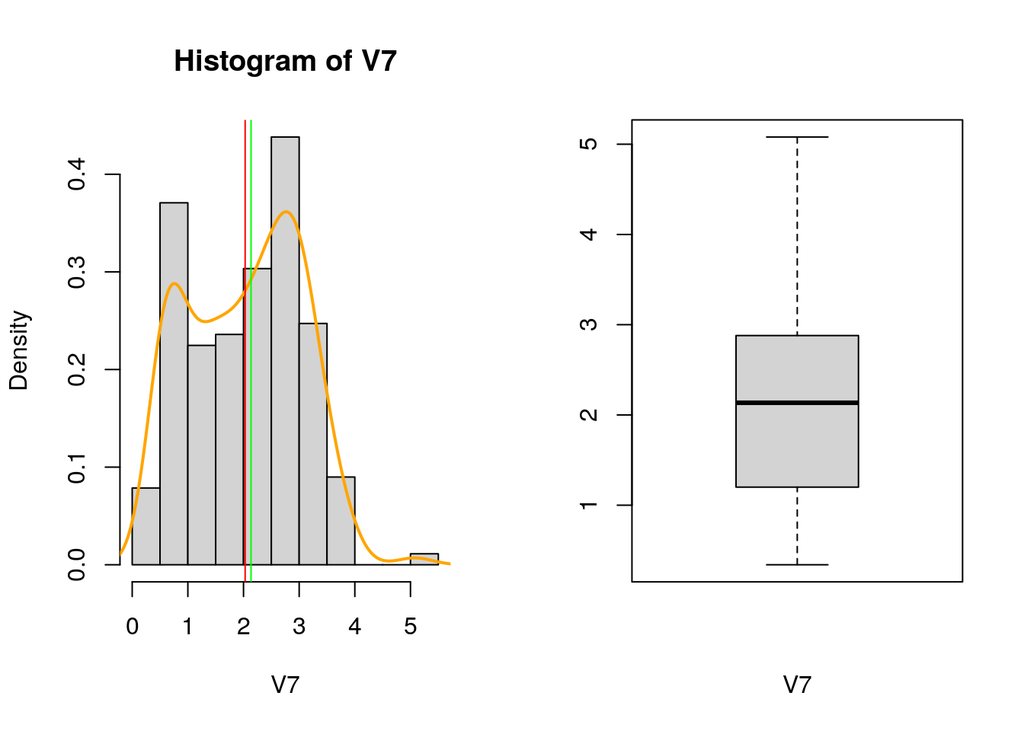

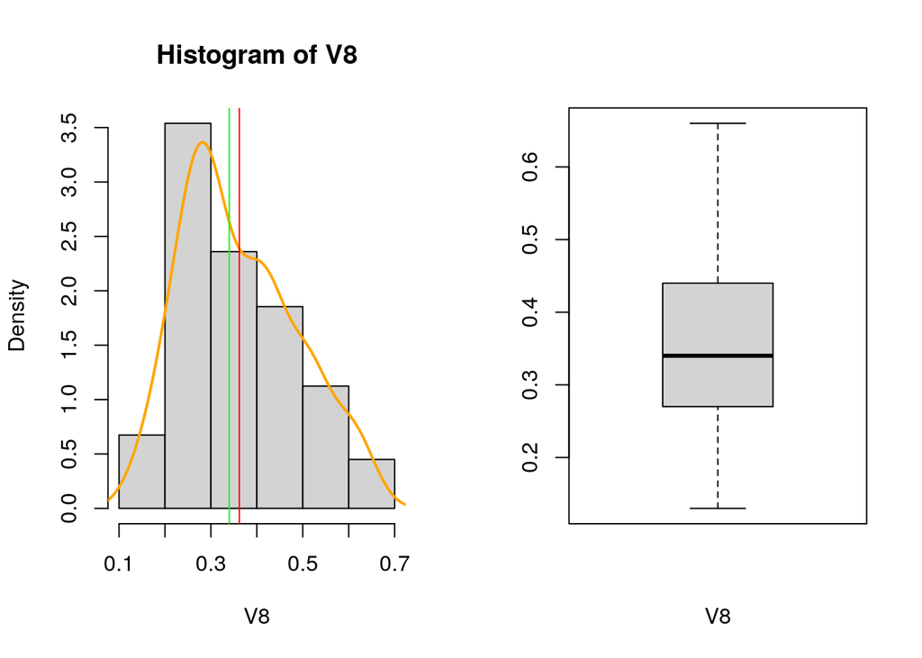

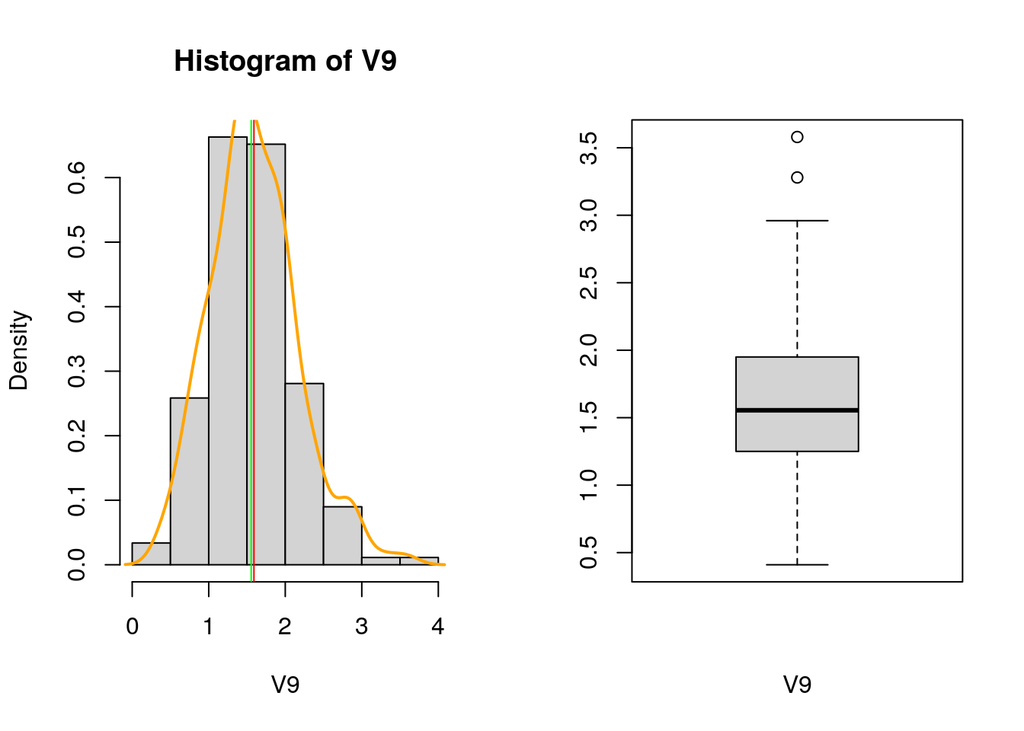

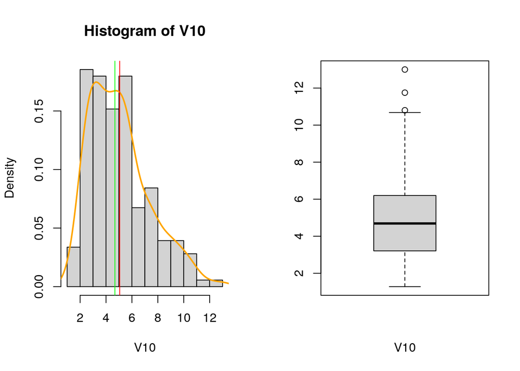

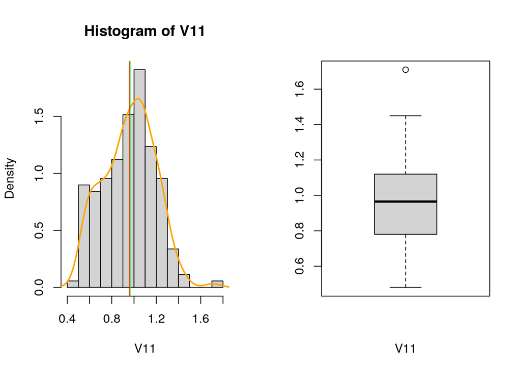

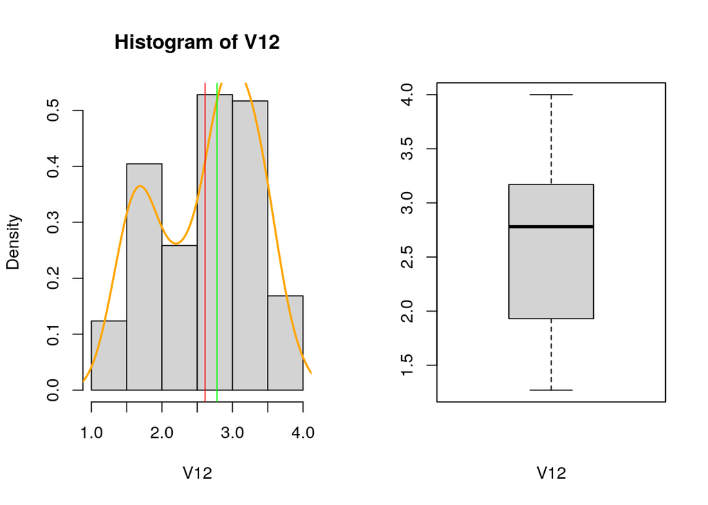

[1 more figures not shown]

```
## [1] "Skewness indexes"
##          V1          V2          V3          V4          V5          V6
## -0.05104747  1.03086950 -0.17520678  0.21124733  1.08891489  0.08590677
##          V7          V8          V9         V10         V11         V12
##  0.02512948  0.44634901  0.51276903  0.86124805  0.02091312 -0.30468993
##         V13
##  0.76133617
## [1] "Kurtosis indexes - 3"
##         V1         V2         V3         V4         V5         V6         V7
## -0.8622601  0.2573483  1.0785761  0.4408231  2.0128060 -0.8458573 -0.8893650
##         V8         V9        V10        V11        V12        V13
## -0.6529522  0.5056710  0.3373698 -0.3680254 -1.0896753 -0.2749997
```

```r
numeric.graph(wine, 2:14)
```

```r
cor(wine[, 2:6], method = "pearson")
```

```
##             V1          V2        V3          V4          V5
## V1  1.00000000  0.09439694 0.2115446 -0.31023514  0.27079823
## V2  0.09439694  1.00000000 0.1640455  0.28850040 -0.05457510
## V3  0.21154460  0.16404547 1.0000000  0.44336719  0.28658669
## V4 -0.31023514  0.28850040 0.4433672  1.00000000 -0.08333309
## V5  0.27079823 -0.05457510 0.2865867 -0.08333309  1.00000000
```

Moreover, discuss the results given by the scatterplot matrix considered below, which considers the first 5 numerical variables, with colours indicating cultivar 1 (black), cultivar 2 (red) and cultivar 3 (blue).

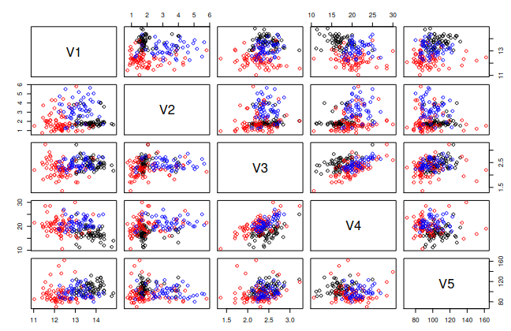

The aim of the study is to adequately synthesize the information given by the original variables V1-V13, in order to capture as much of the information as possible. A further objective is to use some of these new derived variable for distinguishing the three different cultivars. The Principal Components Analysis procedure is applied. Present the main features of this statistical procedure, describe the arguments specified below in the function princomp and discuss the output of the function loadings.

```r
wine.pca <- princomp(wine[2:14], cor=TRUE)
loadings(wine.pca)[,1:4]
```

```
##           Comp.1       Comp.2      Comp.3      Comp.4
## V1   0.144329395  0.483651548  0.20738262  0.01785630
## V2  -0.245187580  0.224930935 -0.08901289 -0.53689028
## V3  -0.002051061  0.316068814 -0.62622390  0.21417556
## V4  -0.239320405 -0.010590502 -0.61208035 -0.06085941
## V5   0.141992042  0.299634003 -0.13075693  0.35179658
## V6   0.394660845  0.065039512 -0.14617896 -0.19806835
## V7   0.422934297 -0.003359812 -0.15068190 -0.15229479
## V8  -0.298533103  0.028779488 -0.17036816  0.20330102
## V9   0.313429488  0.039301722 -0.14945431 -0.39905653
## V10 -0.088616705  0.529995672  0.13730621 -0.06592568
## V11  0.296714564 -0.279235148 -0.08522192  0.42777141
## V12  0.376167411 -0.164496193 -0.16600459 -0.18412074
## V13  0.286752227  0.364902832  0.12674592  0.23207086
```

Questa è la matrice dei loadings (i coefficienti) delle prime quattro componenti principali.

La prima componente principale dà maggior peso a V7, V6 e V12, con pesi abbastanza simili.

La seconda componente principale dà maggior peso a V1, V10 e V13. I loadings di V11 sono molto simili (in valore assoluto).

La terza componente dà maggior peso a V3 e V4.

Moreover, discuss the following graphical outputs

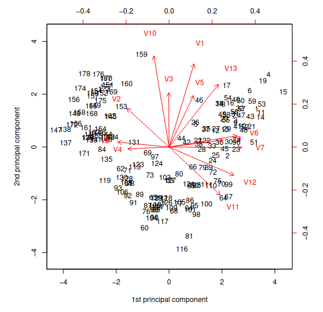

- V6, V9, V7, V12, V11
- V8 e V4
- V10, V3, V1, V5, V13
- V2, a metà tra il secondo e il terzo gruppo di variabili

Ne deduciamo che per spiegare la gran parte della varianza del dataset sono necessarie circa 4/5 componenti principali.

In questo biplot si può notare la disposizione delle osservazioni rispetto alle prime due componenti principali. Si può notare una certa simmetria delle osservazioni rispetto alla prima componente principale.

C’è una regione del grafico in cui sono presenti pochissime informazioni, quella corrispondente alla fascia (-2,2) sulla prima componente e (3,4.5) sulla seconda, a indicare che non ci sono vini con V7, V6, V12 nella media e alti valori di V1, V10, V13.

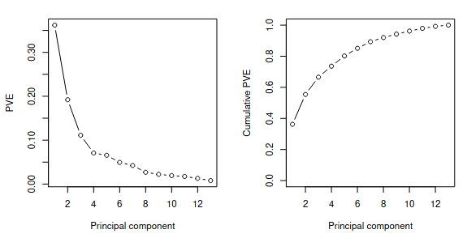

I grafici supportano l’ipotesi sul numero di componenti principali necessarie fatte in precedenza, infatti si nota come in corrispondenza della quinta componente principale la varianza spiegata delle singole componenti sia trascurabile e si raggiunga circa l’80% di varianza cumulata.

Finally, comment this last plot, with particular concern to the aim of characterizing the three different cultivars.

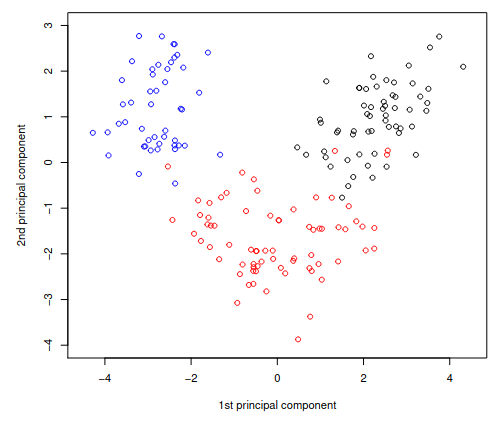

Da questo scatterplot si notano tre cluster di dati (corrispondenti ai tre fattori) di cultivar, confermando l’ipotesi iniziale che fosse possibile classificare i vini in base alle componenti principali (in questo caso ne bastano due).